# Panel Regression (Fatalities dataset)

2026-01-29

```r
library(AER)
library(plm)
data(Fatalities)
```

# Exogeneity vs Endogeneity (OLS vs Fixed Effects)

**Exogeneity** means the regressor is uncorrelated with the error term, i.e., a variable (regressor) is not influenced by outcome variable and not correlated to the error term (idiosyncratic error).

**Endogeneity** means that the regressor is correlated to the error term (and unobserved variables). **Endogeneity** can arise from -

1. *Reverse Causality* — Y affects X instead of (or alongside) X affecting Y. Example: high fatalities cause states to raise beer taxes, not just the other way around. Requires Instrumental Variables (IV) to address.
2. *Omitted Variable Bias* — A relevant variable Z is left out. If Z affects Y and correlates with X, it ends up in the error term, contaminating it. Requires inclusion of omitted variables or Instrumental Variables (IV) to address.
3. *Unobserved Fixed Effects* — Each unit has time-invariant traits αᵢ that affect Y. Running plain OLS ignores αᵢ, which gets absorbed into the error. If X correlates with αᵢ, endogeneity follows.

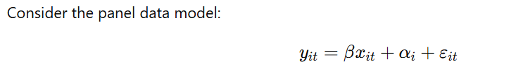

- **In OLS, regressor follows exogeneous relation with both the fixed effect (alpha term) and idiosyncratic error.**

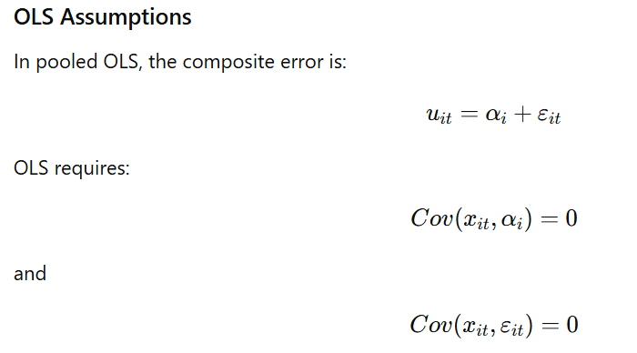

- **In fixed effects regression, regressors are required to be exogenous only with respect to the idiosyncratic error, while they may be endogenous with respect to the fixed effects term.**

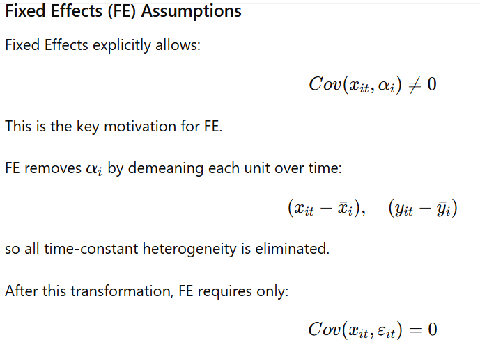

###############################################################################

## The following codes are copied from - https://www.econometrics-with-r.org/10.1-panel-data.html

```r
# pdata.frame() declares the data as panel data.
Fatalities <-pdata.frame(Fatalities, index= c('state', 'year'))

dim(Fatalities)
```

```
## [1] 336  34
```

```r
summary(Fatalities[, c(1, 2)])
```

```
##      state       year
##  al     :  7   1982:48
##  az     :  7   1983:48
##  ar     :  7   1984:48
##  ca     :  7   1985:48
##  co     :  7   1986:48
##  ct     :  7   1987:48
##  (Other):294   1988:48
```

```r
head(Fatalities)
```

```
##         state year spirits unemp   income   emppop  beertax baptist  mormon
## al-1982    al 1982    1.37  14.4 10544.15 50.69204 1.539379 30.3557 0.32829
## al-1983    al 1983    1.36  13.7 10732.80 52.14703 1.788991 30.3336 0.34341
## al-1984    al 1984    1.32  11.1 11108.79 54.16809 1.714286 30.3115 0.35924
## al-1985    al 1985    1.28   8.9 11332.63 55.27114 1.652542 30.2895 0.37579
## al-1986    al 1986    1.23   9.8 11661.51 56.51450 1.609907 30.2674 0.39311
## al-1987    al 1987    1.18   7.8 11944.00 57.50988 1.560000 30.2453 0.41123
##         drinkage     dry youngdrivers    miles breath jail service fatal nfatal
## al-1982    19.00 25.0063     0.211572 7233.887     no   no      no   839    146
## al-1983    19.00 22.9942     0.210768 7836.348     no   no      no   930    154
## al-1984    19.00 24.0426     0.211484 8262.990     no   no      no   932    165
## al-1985    19.67 23.6339     0.211140 8726.917     no   no      no   882    146
## al-1986    21.00 23.4647     0.213400 8952.854     no   no      no  1081    172
## al-1987    21.00 23.7924     0.215527 9166.302     no   no      no  1110    181
##         sfatal fatal1517 nfatal1517 fatal1820 nfatal1820 fatal2124 nfatal2124
## al-1982     99        53          9        99         34       120         32
## al-1983     98        71          8       108         26       124         35
## al-1984     94        49          7       103         25       118         34
## al-1985     98        66          9       100         23       114         45
## al-1986    119        82         10       120         23       119         29
## al-1987    114        94         11       127         31       138         30
##          afatal     pop  pop1517  pop1820  pop2124 milestot unempus emppopus
## al-1982 309.438 3942002 208999.6 221553.4 290000.1    28516     9.7     57.8
## al-1983 341.834 3960008 202000.1 219125.5 290000.2    31032     9.6     57.9
## al-1984 304.872 3988992 197000.0 216724.1 288000.2    32961     7.5     59.5
## al-1985 276.742 4021008 194999.7 214349.0 284000.3    35091     7.2     60.1
## al-1986 360.716 4049994 203999.9 212000.0 263000.3    36259     7.0     60.7
## al-1987 368.421 4082999 204999.8 208998.5 258999.8    37426     6.2     61.5
##                 gsp
## al-1982 -0.02212476
## al-1983  0.04655825
## al-1984  0.06279784
## al-1985  0.02748997
## al-1986  0.03214295
## al-1987  0.04897637
```

```r
# define fatalities rate (number of fatalities per 10000 inhabitants)
Fatalities$fatal_rate <- Fatalities$fatal / Fatalities$pop * 10000

# subset
Fatalities1982 <- subset(Fatalities, year == '1982')
Fatalities1988 <- subset(Fatalities, year == '1988')
```

# Linear regression

```r
# estimate simple regression models using the 1982 and 1988 data
fatal1982_mod <- lm(fatal_rate ~ beertax, data = Fatalities1982)
fatal1988_mod <- lm(fatal_rate ~ beertax, data = Fatalities1988)

# fatal1982_mod

coeftest(
  fatal1982_mod,     # your regression model
  vcov. = vcovHC,    # use a robust variance-covariance matrix
  type = "HC1"       # use HC1 version of robust SEs
)
```

```
##
## t test of coefficients:
##
##             Estimate Std. Error t value Pr(>|t|)
## (Intercept)  2.01038    0.14957 13.4408   <2e-16 ***
## beertax      0.14846    0.13261  1.1196   0.2687
## ---
## Signif. codes:  0 '***' 0.001 '**' 0.01 '*' 0.05 '.' 0.1 ' ' 1
```

```r
print('----------------------')
```

```
## [1] "----------------------"
```

```r
coeftest(
  fatal1988_mod,     # your regression model
  vcov. = vcovHC,    # use a robust variance-covariance matrix
  type = 'HC1')
```

```
##
## t test of coefficients:
##
##             Estimate Std. Error t value  Pr(>|t|)
## (Intercept)  1.85907    0.11461 16.2205 < 2.2e-16 ***
## beertax      0.43875    0.12786  3.4314  0.001279 **
## ---
## Signif. codes:  0 '***' 0.001 '**' 0.01 '*' 0.05 '.' 0.1 ' ' 1
```

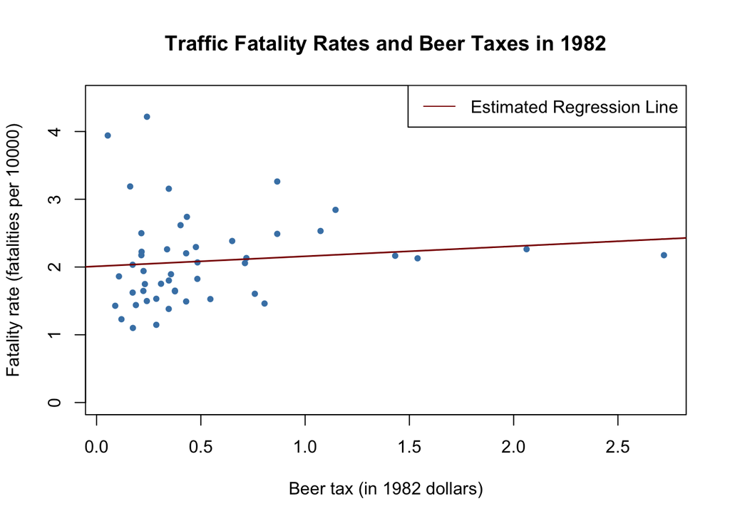

```r
# plot the observations and add the estimated regression line for 1982 data

plot(x = as.double(Fatalities1982$beertax),
     y = as.double(Fatalities1982$fatal_rate),
     xlab = "Beer tax (in 1982 dollars)",
     ylab = "Fatality rate (fatalities per 10000)",
     main = "Traffic Fatality Rates and Beer Taxes in 1982",
     ylim = c(0, 4.5),
     pch=20, col = 'steelblue')

abline(fatal1982_mod, lwd=1.5, col='darkred')
legend('topright', lty=1, col='darkred', "Estimated Regression Line")
```

[figure not shown]

```r
# plot the observations and add the estimated regression line for 1988 data

plot(x = as.double(Fatalities1988$beertax),
     y = as.double(Fatalities1988$fatal_rate),
     xlab = "Beer tax (in 1988 dollars)",
     ylab = "Fatality rate (fatalities per 10000)",
     main = "Traffic Fatality Rates and Beer Taxes in 1988",
     ylim = c(0, 4.5),
     pch=20, col = 'steelblue')

abline(fatal1982_mod, lwd=1.5, col='darkred')
legend('topright', lty=1, col='darkred', "Estimated Regression Line")
```

*In both plots, each point represents observations of beer tax and fatality rate for a given state in the respective year. The regression results indicate a positive relationship between the beer tax and the fatality rate for both years. The estimated coefficient on beer tax for the 1988 data is almost three times as large as for the 1982 dataset. This is contrary to our expectations: alcohol taxes are supposed to lower the rate of traffic fatalities. This is possibly due to omitted variable bias, since both models do not include any covariates, e.g., economic conditions. This could be corrected by using a multiple regression approach. However, this cannot account for omitted unobservable factors that differ from state to state but can be assumed to be constant over the observation span, e.g., the populations’ attitude towards drunk driving.*

**This is what Panel Regression tries to overcome.**

# Why Panel Regression works?

To address this bias from unobserved variable, let’s 1st consider that

```r
# compute the differences
diff_fatal_rate <- Fatalities1988$fatal_rate - Fatalities1982$fatal_rate
diff_beertax <- Fatalities1988$beertax - Fatalities1982$beertax

# estimate a regression using differenced data
fatal_diff_mod <- lm(diff_fatal_rate ~ diff_beertax)

coeftest(fatal_diff_mod, vcov = vcovHC, type='HC1')
```

```
##
## t test of coefficients:
##
##               Estimate Std. Error t value Pr(>|t|)
## (Intercept)  -0.072037   0.065355 -1.1022 0.276091
## diff_beertax -1.040973   0.355006 -2.9323 0.005229 **
## ---
## Signif. codes:  0 '***' 0.001 '**' 0.01 '*' 0.05 '.' 0.1 ' ' 1
```

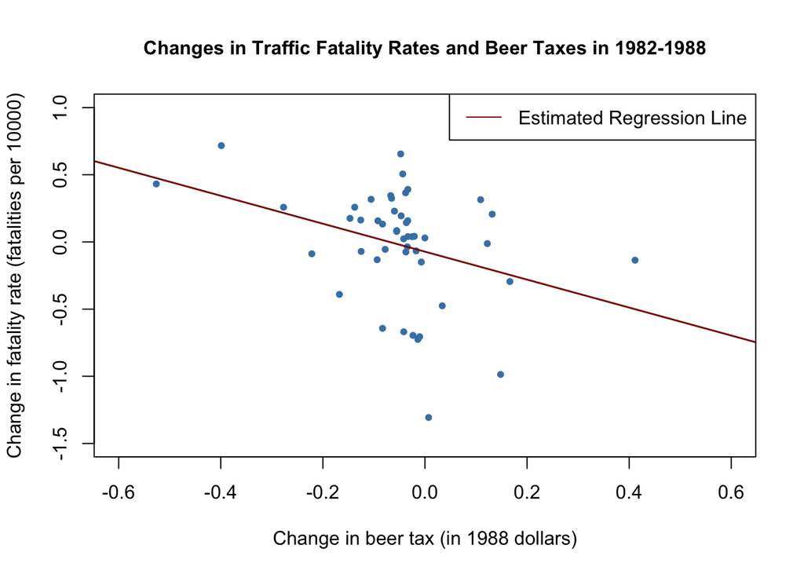

```r
# plot the differenced data
plot(x = as.double(diff_beertax),
     y = as.double(diff_fatal_rate),
     xlab = "Change in beer tax (in 1988 dollars)",
     ylab = "Change in fatality rate (fatalities per 10000)",
     main = "Changes in Traffic Fatality Rates and Beer Taxes in 1982-1988",
     cex.main=1,
     xlim = c(-0.6, 0.6),
     ylim = c(-1.5, 1),
     pch = 20,
     col = "steelblue")

# add the regression line to plot
abline(fatal_diff_mod, lwd = 1.5,col="darkred")
#add legend
legend("topright",lty=1,col="darkred","Estimated Regression Line")
```

*The negative slope between beertax and change in fatality rate is the true relation between these variables, which was masked by other time-invariant state-level effects. Negating out the state effects and doing the linear modeling on the state effect-removed variables brings out the true relationship.*

**This is what Panel Regression modeling is about.**

# Fixed Effects Panel Regression

## State Fixed Effects Consideration

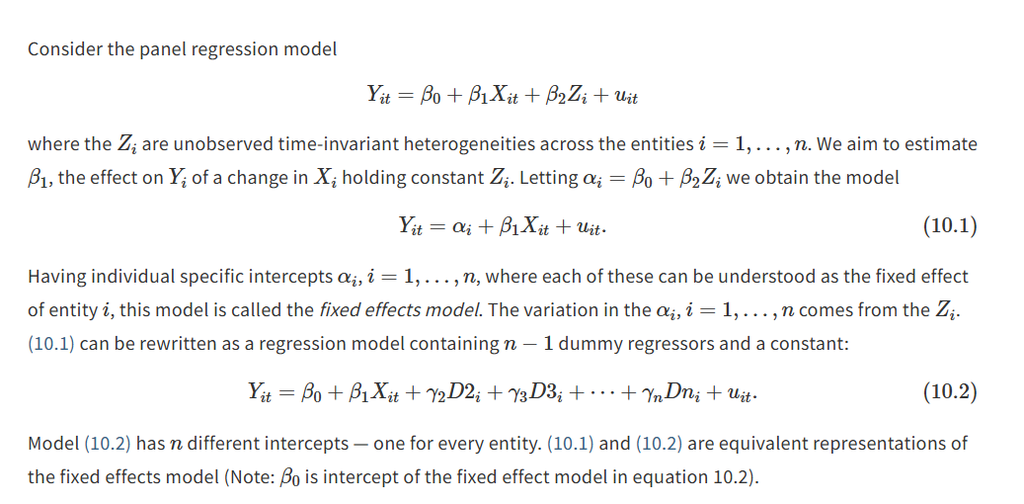

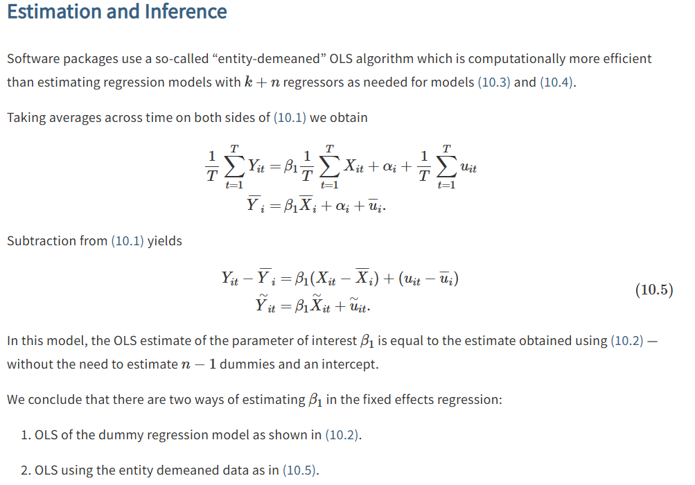

**The discussions above establish that using either approach - using dummy variables or demeaning - has the same effect to control the fixed effects.**

```r
# dummy variable approach

fatal_fe_lm_mod <- lm(fatal_rate ~ beertax + state - 1, data=Fatalities)

fatal_fe_lm_mod
```

```
##
## Call:
## lm(formula = fatal_rate ~ beertax + state - 1, data = Fatalities)
##
## Coefficients:
## beertax  stateal  stateaz  statear  stateca  stateco  statect  statede
## -0.6559   3.4776   2.9099   2.8227   1.9682   1.9933   1.6154   2.1700
## statefl  statega  stateid  stateil  statein  stateia  stateks  stateky
##  3.2095   4.0022   2.8086   1.5160   2.0161   1.9337   2.2544   2.2601
## statela  stateme  statemd  statema  statemi  statemn  statems  statemo
##  2.6305   2.3697   1.7712   1.3679   1.9931   1.5804   3.4486   2.1814
## statemt  statene  statenv  statenh  statenj  statenm  stateny  statenc
##  3.1172   1.9555   2.8769   2.2232   1.3719   3.9040   1.2910   3.1872
## statend  stateoh  stateok  stateor  statepa  stateri  statesc  statesd
##  1.8542   1.8032   2.9326   2.3096   1.7102   1.2126   4.0348   2.4739
## statetn  statetx  stateut  statevt  stateva  statewa  statewv  statewi
##  2.6020   2.5602   2.3137   2.5116   2.1874   1.8181   2.5809   1.7184
## statewy
##  3.2491
```

Notice that, using lm() approach returns the coefficients of the dummies (states in this case). They represent each state’s baseline fatality rate when `beertax=0`. In other words - `A state-specific average fatality rate, capturing all time-invariant factors about that state.`

```r
## demeaning approach

# creating a demeaned dataframe
fatal_demean <- with(Fatalities,
                     data.frame(fatal_rate = fatal_rate - ave(fatal_rate, state),
                     beertax = beertax - ave(beertax, state)))

fatal_demean
```

```
##        fatal_rate       beertax
## 1   -0.2842671329 -0.0844132049
## 2   -0.0641470520  0.1651980536
## 3   -0.0761971547  0.0904929297
## 4   -0.2191471758  0.0287496703
## 5    0.2565127654 -0.0138856513
## 6    0.3059627823 -0.0637927396
## 7    0.0812829677 -0.1223490579
## 8   -0.2067599951 -0.0962432155
## 9   -0.4385200179 -0.1046183237
## 10   0.1228799025 -0.0143370458
## 11   0.0961098638  0.0703155867
## 12   0.3651600699  0.0604766778
## 13   0.0613800351  0.0489596597
## 14  -0.0002498583  0.0354466609
```

[output cut: 322 more lines]

```r
# estimate the panel regression
summary(lm(fatal_rate ~ beertax -1, data=fatal_demean))
```

```
##
## Call:
## lm(formula = fatal_rate ~ beertax - 1, data = fatal_demean)
##
## Residuals:
##      Min       1Q   Median       3Q      Max
## -0.58696 -0.08284 -0.00127  0.07955  0.89780
##
## Coefficients:
##         Estimate Std. Error t value Pr(>|t|)
## beertax  -0.6559     0.1739  -3.772 0.000191 ***
## ---
## Signif. codes:  0 '***' 0.001 '**' 0.01 '*' 0.05 '.' 0.1 ' ' 1
##
## Residual standard error: 0.1757 on 335 degrees of freedom
## Multiple R-squared:  0.04074,    Adjusted R-squared:  0.03788
## F-statistic: 14.23 on 1 and 335 DF,  p-value: 0.0001913
```

*Notice that the coefficient of ‘beertax’ is the same from both approach.*

```r
# panel regression with 'plm' library
fatal_fe_mod <- plm(fatal_rate ~ beertax,
                    data=Fatalities,
                    index=c('state', 'year'),
                    model='within')

coeftest(fatal_fe_mod, vcov=vcovHC, type='HC1')
```

```
##
## t test of coefficients:
##
##         Estimate Std. Error t value Pr(>|t|)
## beertax -0.65587    0.28880  -2.271  0.02388 *
## ---
## Signif. codes:  0 '***' 0.001 '**' 0.01 '*' 0.05 '.' 0.1 ' ' 1
```

*Note that plm() uses the entity-demeaned OLS algorithm and thus does not report dummy coefficients.*

**Although including state fixed effects eliminates the risk of a bias due to omitted factors that vary across states but not over time, we suspect that there are other omitted variables that vary over time and thus cause a bias.**

## Time Fixed Effects Consideration

Like state-specific fixed effects, there can be time-specific fixed effects. I like to think them as ‘time shocks’, e.g., let’s say some incidents happen and affects the entire nation.

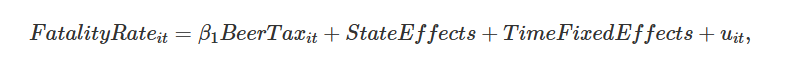

```r
#using plm() here

fatal_tefe_mod <-
  plm(fatal_rate ~ beertax,
  data = Fatalities,
  index = c('state', 'year'),
  model = 'within',     # this indicates that this is a fixed effects regression
  effect = 'twoways')   # 'twoways' indicate that we are considering both state and time fixed effects

coeftest(fatal_tefe_mod, vcov = vcovHC, type='HC1')
```

```
##
## t test of coefficients:
##
##         Estimate Std. Error t value Pr(>|t|)
## beertax -0.63998    0.35015 -1.8277  0.06865 .
## ---
## Signif. codes:  0 '***' 0.001 '**' 0.01 '*' 0.05 '.' 0.1 ' ' 1
```

`Adding year fixed effects does not materially change the estimated magnitude of the BeerTax effect.`

# Fundamental Assumptions behind Fixed Effects Regression

`Let's say we are working with the model above where we are correalting fatalities from road accident and BeerTax for all states within CONUS.`

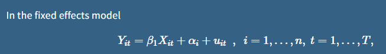

*Assumption 1.* Within a given unit (state), after controlling for all observed regressors over time, there is - `No systematic relationship between the error term and the regressor.` It means that, unexpected shocks to fatalities (the error term in Y) do not affect BeerTax — now or in the future (*`exogenous relationship`*). In simplistic term, fatalities (y) can’t effect BeerTax.

**It breaks** when -

- Reverse causality (fatalities affect BeerTax).
- Omitted time-varying factors. Fixed effect regression only controls time-invariant factors.

*Assumption 2.* Independent and identically distributed random variables across units (not time). This means that -

- Different states are treated as independent draws.
- But within a state, observations over time can be correlated (serial correlation within state; heteroskedasticity allowed).

**It breaks** when -

- Spillover across states.
- National shocks not absorbed in time FE (if omitted). `This is why we may need to consider time fixed effects.

*Assumption 3.* No extreme outliers (finite fourth moments). This is a technical condition that ensures -

- Law of large numbers
- Central limit theorem
- Valid standard error

**It breaks** when -

- Heavy tailed distribution.
- Extreme leverage points.

*Assumption 4.* No perfect multicollinearity. This means-

- No regressor is a perfect linear combination of others
- In FE model, this implies that we can’t include
  - state area;
  - climate normals;
  - baseline demographics;

    as they are perfectly collinear with αi.
- **We can only keep variables or regressors that change within units over time.**

## Note on Standard Error for Fixed Effects Regression

In fixed effects regressions, the presence of autocorrelation within entities invalidates the usual standard error formulas, as well as heteroskedasticity-robust standard errors, which assume no serial correlation. When errors are both heteroskedastic and autocorrelated, heteroskedasticity- and autocorrelation-consistent (HAC) standard errors are required. Clustered standard errors belong to this class and allow for arbitrary heteroskedasticity and autocorrelation within an entity, while assuming independence across entities. In panel data applications, clustering is therefore typically done at the entity level. In practice, functions such as `vcovHC()` from the **sandwich** package compute clustered standard errors automatically for fixed effects models estimated using `plm()`. By contrast, when fixed effects are estimated using `lm()` with dummy variables, standard inference procedures do not cluster errors by default, making clustered standard errors essential for valid inference.

```r
# Fixed effect via lm()
fatal_tefe_lm_mod <- lm(fatal_rate ~ beertax + state + year - 1, data = Fatalities)

class(fatal_tefe_lm_mod)
```

```
## [1] "lm"
```

```r
coeftest(fatal_tefe_lm_mod, vcov = vcovHC, type = "HC1")[1, ]
```

```
##   Estimate Std. Error    t value   Pr(>|t|)
## -0.6399800  0.2547149 -2.5125346  0.0125470
```

`Fixed effects regression with lm() return beta_1 which looks` **statistically significant.** Note that, here, the SE is relatively low but doesn’t consider autocorrealtion (within state over time).

```r
class(fatal_tefe_mod)
```

```
## [1] "plm"        "panelmodel"
```

```r
coeftest(fatal_tefe_mod, vcov = vcovHC, type='HC1')
```

```
##
## t test of coefficients:
##
##         Estimate Std. Error t value Pr(>|t|)
## beertax -0.63998    0.35015 -1.8277  0.06865 .
## ---
## Signif. codes:  0 '***' 0.001 '**' 0.01 '*' 0.05 '.' 0.1 ' ' 1
```

`Fixed effects regression with plm() return beta_1 isn't` **statistically significant.** Note that, here, the SE is clustered and is relatively higher than lm()-based FE. Most importantly, it considers autocorrealtion (within state over time).

# Considering other omitted variables into the Panel Regression Model

```r
# discretize the minimum legal drinking age
Fatalities$drinkagec <- cut(Fatalities$drinkage,
                            breaks = 18:22,
                            include.lowest = TRUE,
                            right = FALSE)

# set minimum drinking age [21, 22] to be the baseline level
# “How do fatality rates differ when the drinking age is below 21, relative to when it is 21 or older?”
Fatalities$drinkagec <- relevel(Fatalities$drinkagec, "[21,22]")


# mandatory jail or community service?
Fatalities$punish <- factor(
  (Fatalities$jail == "yes") | (Fatalities$service == "yes"),
  levels = c(FALSE, TRUE),
  labels = c("no", "yes")
)

# the set of observations on all variables for 1982 and 1988
fatal_1982_1988 <- Fatalities[with(Fatalities, year == 1982 | year == 1988), ]

head(Fatalities)
```

```
##         state year spirits unemp   income   emppop  beertax baptist  mormon
## al-1982    al 1982    1.37  14.4 10544.15 50.69204 1.539379 30.3557 0.32829
## al-1983    al 1983    1.36  13.7 10732.80 52.14703 1.788991 30.3336 0.34341
## al-1984    al 1984    1.32  11.1 11108.79 54.16809 1.714286 30.3115 0.35924
## al-1985    al 1985    1.28   8.9 11332.63 55.27114 1.652542 30.2895 0.37579
## al-1986    al 1986    1.23   9.8 11661.51 56.51450 1.609907 30.2674 0.39311
## al-1987    al 1987    1.18   7.8 11944.00 57.50988 1.560000 30.2453 0.41123
##         drinkage     dry youngdrivers    miles breath jail service fatal nfatal
## al-1982    19.00 25.0063     0.211572 7233.887     no   no      no   839    146
## al-1983    19.00 22.9942     0.210768 7836.348     no   no      no   930    154
## al-1984    19.00 24.0426     0.211484 8262.990     no   no      no   932    165
## al-1985    19.67 23.6339     0.211140 8726.917     no   no      no   882    146
## al-1986    21.00 23.4647     0.213400 8952.854     no   no      no  1081    172
## al-1987    21.00 23.7924     0.215527 9166.302     no   no      no  1110    181
##         sfatal fatal1517 nfatal1517 fatal1820 nfatal1820 fatal2124 nfatal2124
## al-1982     99        53          9        99         34       120         32
## al-1983     98        71          8       108         26       124         35
## al-1984     94        49          7       103         25       118         34
## al-1985     98        66          9       100         23       114         45
## al-1986    119        82         10       120         23       119         29
## al-1987    114        94         11       127         31       138         30
##          afatal     pop  pop1517  pop1820  pop2124 milestot unempus emppopus
## al-1982 309.438 3942002 208999.6 221553.4 290000.1    28516     9.7     57.8
## al-1983 341.834 3960008 202000.1 219125.5 290000.2    31032     9.6     57.9
## al-1984 304.872 3988992 197000.0 216724.1 288000.2    32961     7.5     59.5
## al-1985 276.742 4021008 194999.7 214349.0 284000.3    35091     7.2     60.1
## al-1986 360.716 4049994 203999.9 212000.0 263000.3    36259     7.0     60.7
## al-1987 368.421 4082999 204999.8 208998.5 258999.8    37426     6.2     61.5
##                 gsp fatal_rate drinkagec punish
## al-1982 -0.02212476    2.12836   [19,20)     no
## al-1983  0.04655825    2.34848   [19,20)     no
## al-1984  0.06279784    2.33643   [19,20)     no
## al-1985  0.02748997    2.19348   [19,20)     no
## al-1986  0.03214295    2.66914   [21,22]     no
## al-1987  0.04897637    2.71859   [21,22]     no
```

```r
# estimate all seven models
fat_mod1 <- lm(fatal_rate ~ beertax, data = Fatalities)

fat_mod2 <- plm(fatal_rate ~ beertax + state, data = Fatalities)

fat_mod3 <- plm(fatal_rate ~ beertax + state + year,
                       index = c("state","year"),
                       model = "within",
                       effect = "twoways",
                       data = Fatalities)

fat_mod4 <- plm(fatal_rate ~ beertax + state + year + drinkagec
                       + punish + miles + unemp + log(income),
                       index = c("state", "year"),
                       model = "within",
                       effect = "twoways",
                       data = Fatalities)

fat_mod5 <- plm(fatal_rate ~ beertax + state + year + drinkagec
                       + punish + miles,
                       index = c("state", "year"),
                       model = "within",
                       effect = "twoways",
                       data = Fatalities)

fat_mod6 <- plm(fatal_rate ~ beertax + year + drinkage
                       + punish + miles + unemp + log(income),
                       index = c("state", "year"),
                       model = "within",
                       effect = "twoways",
                       data = Fatalities)

fat_mod7 <- plm(fatal_rate ~ beertax + state + year + drinkagec
                       + punish + miles + unemp + log(income),
                       index = c("state", "year"),
                       model = "within",
                       effect = "twoways",
                       data = fatal_1982_1988)
```

```r
library(stargazer)

# gather clustered standard errors in a list
rob_se <- list(sqrt(diag(vcovHC(fat_mod1, type = "HC1"))),
               sqrt(diag(vcovHC(fat_mod2, type = "HC1"))),
               sqrt(diag(vcovHC(fat_mod3, type = "HC1"))),
               sqrt(diag(vcovHC(fat_mod4, type = "HC1"))),
               sqrt(diag(vcovHC(fat_mod5, type = "HC1"))),
               sqrt(diag(vcovHC(fat_mod6, type = "HC1"))),
               sqrt(diag(vcovHC(fat_mod7, type = "HC1"))))

## generate the table
## The following code block isn't working. The expected table's snip is provided below.

#stargazer(fat_mod1,
#          fat_mod2,
#          fat_mod3,
#          fat_mod4,
#          fat_mod5,
#          fat_mod6,
#          fat_mod7,
#          digits = 3,
#          header = FALSE,
#          type = "latex",
#          se = rob_se,
#          title = "Linear Panel Regression Models of Traffic Fatalities
#                                                      due to Drunk Driving",
#          model.numbers = FALSE,
#          column.labels = c("(1)", "(2)", "(3)", "(4)", "(5)", "(6)", "(7)"))
```

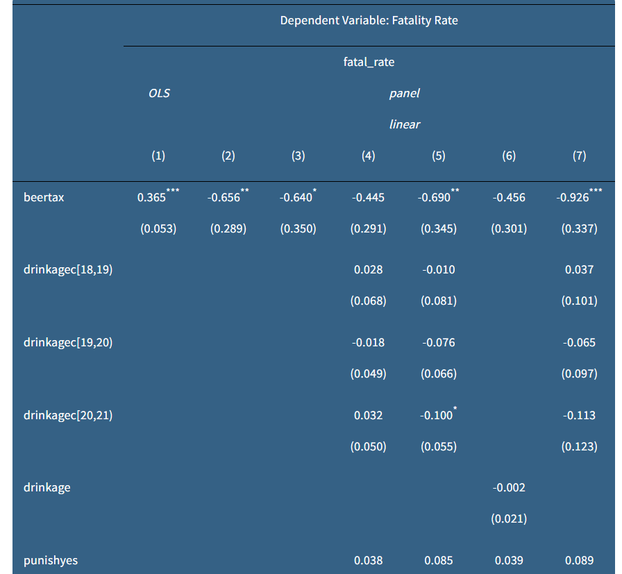

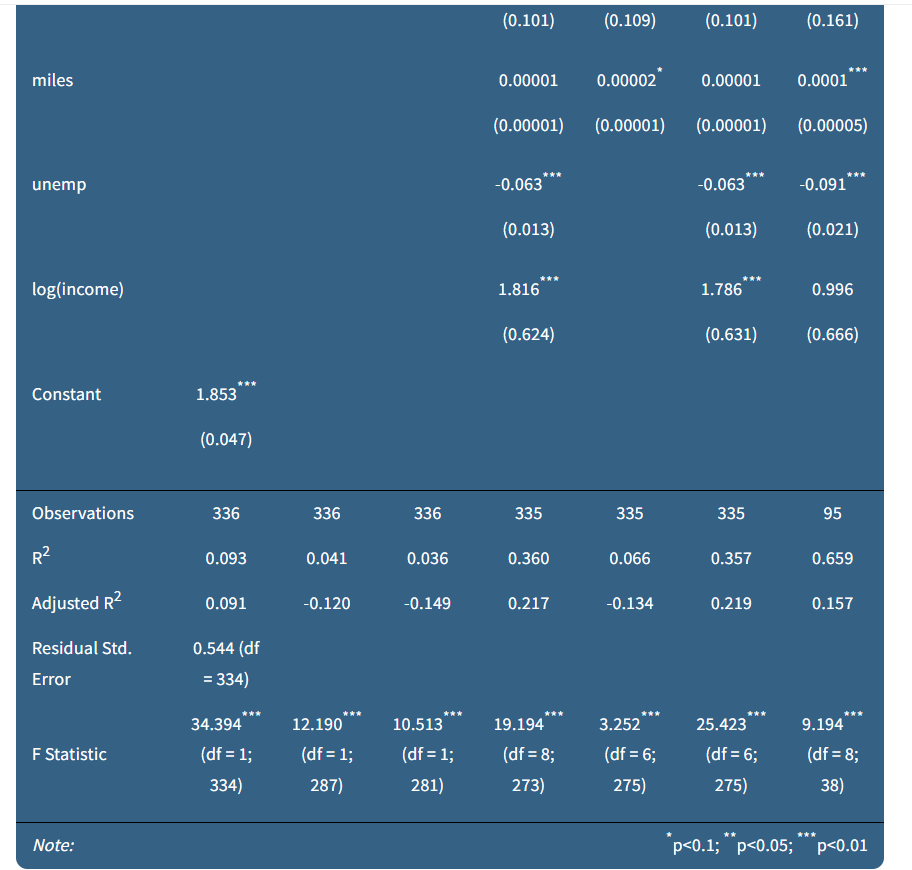

### Hypothesis Testing

`We want to statistically see if drinking age or economic variables have any influence on fatalities rate.` We can test such hypothesis by `F-test`. The F-test checks the joint hypothesis that if variables (regressors) considered under the hypothesis test are all zero (null hypothesis) or not (alternate hypothesis).

```r
# test if legal drinking age has no explanatory power
linearHypothesis(fat_mod4,
                 test='F',
                 c("drinkagec[18,19)=0", "drinkagec[19,20)=0", "drinkagec[20,21)"),
                 vcov. = vcovHC, type = "HC1")
```

```
##
## Linear hypothesis test:
## drinkagec[18,19) = 0
## drinkagec[19,20) = 0
## drinkagec[20,21) = 0
##
## Model 1: restricted model
## Model 2: fatal_rate ~ beertax + state + year + drinkagec + punish + miles +
##     unemp + log(income)
##
## Note: Coefficient covariance matrix supplied.
##
##   Res.Df Df      F Pr(>F)
## 1    276
## 2    273  3 0.3782 0.7688
```

There is no evidence that punishment for first offenders has a deterring effects on drunk driving: the corresponding coefficient is not significant at the 10% level.

```r
# test if economic indicators have no explanatory power
linearHypothesis(fat_mod4,
                 test = "F",
                 c("log(income)", "unemp"),
                 vcov. = vcovHC, type = "HC1")
```

```
##
## Linear hypothesis test:
## log(income) = 0
## unemp = 0
##
## Model 1: restricted model
## Model 2: fatal_rate ~ beertax + state + year + drinkagec + punish + miles +
##     unemp + log(income)
##
## Note: Coefficient covariance matrix supplied.
##
##   Res.Df Df      F    Pr(>F)
## 1    275
## 2    273  2 31.577 4.609e-13 ***
## ---
## Signif. codes:  0 '***' 0.001 '**' 0.01 '*' 0.05 '.' 0.1 ' ' 1
```

The result supports the notion that economic indicators should remain in the model as the coefficient on beer tax is sensitive to the inclusion of these factors.

### Important Note

We have not found evidence that severe punishments and increasing the minimum drinking age reduce traffic fatalities due to drunk driving. Nonetheless, there seems to be a negative effect of alcohol taxes on traffic fatalities which, however, is estimated imprecisely and cannot be interpreted as the causal effect of interest as there still may be a bias. The issue is that there may be omitted variables that differ across states and change over time and this bias remains, even though we use a panel approach that controls for `entity-specific` and `time-invariant unobservables`.

**A powerful method that can be used if common panel regression approaches fail is instrumental variables regression.**